# Weight Lifting Exercises Dataset

Shaddy

February 27, 2016

# Weight Lifting Exercises Prediction Model

## Background

Using devices such as Jawbone Up, Nike FuelBand, and Fitbit it is now possible to collect a large amount of data about personal activity relatively inexpensively. These type of devices are part of the quantified self movement - a group of enthusiasts who take measurements about themselves regularly to improve their health, to find patterns in their behavior, or because they are tech geeks. One thing that people regularly do is quantify how much of a particular activity they do, but they rarely quantify how well they do it. In this project, your goal will be to use data from accelerometers on the belt, forearm, arm, and dumbell of 6 participants. They were asked to perform barbell lifts correctly and incorrectly in 5 different ways.

Six young health participants were asked to perform one set of 10 repetitions of the Unilateral Dumbbell Biceps Curl in five different fashions: exactly according to the specification (Class A), throwing the elbows to the front (Class B), lifting the dumbbell only halfway (Class C), lowering the dumbbell only halfway (Class D) and throwing the hips to the front (Class E). Only the class A excercise was performed correctly.

## Objective

The goal of this project is to create a model to accurately predict the type of excercise a participant does based on the variables given. The steps to build the model will be described in detail, as well as how cross validation was used to refine the model. The out of sample error will also be used to increase our confidence in the model.

### Loading and preprocessing the raw data

Given the nature of the raw data, many of the variables must be excluded due to relevance, NAs, and factor variables which impede model selection. Out of the 160 variables given, only 52 were usable.

## Exploratory Model (Model#1): Regression Tree

Since the outcome is a classification, a CART model is a good starting point for looking at important features of the data.

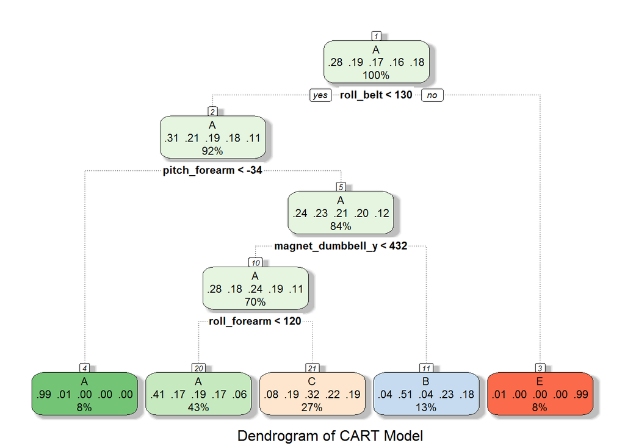

```
##      Accuracy AccuracyLower AccuracyUpper
##     0.4940889     0.4841483     0.5040329
```

Along with a paltry accuracy of ~50% on the training set, the CART model also fails to include a way to classify “Class D!”. However, despite its lacking features, the model is still informative; The “roll_belt” and “pitch_forearm” variables seem like and important distinction between Classes E and A, and the classes.

## Model #2: Linear Discriminant Analysis

By looking at classification by assuming Gaussian clumping, we use linear discriminant analysis to hopefully make better classification predictions.

```
##      Accuracy AccuracyLower AccuracyUpper
##     0.7085202     0.6994164     0.7175000
```

By predicting on the training data, we see a better fit than with the Regression Tree. Also, we finally see all classes have a way of being classified.

```
##      Accuracy AccuracyLower AccuracyUpper
##     0.6940877     0.6848616     0.7031983
```

The validation set, however, shows a decent, but still low ~70% accuracy and an Out-of-Sample rate of 30.59%

## Model#3: Random Forest

By taking the classification tree model even further, we can greatly increase model accuracy. Also, as one of the best predictive models, Random Forests are a big step towards a final model. Cross-validation will be used to improve performance

```
##      Accuracy AccuracyLower AccuracyUpper
##     1.0000000     0.9996241     1.0000000
```

The accuracy on the training set looks very good, but we might be overfitting. We can use a validation set to help verify the model’s true accuracy.

```
##      Accuracy AccuracyLower AccuracyUpper
##     0.9880734     0.9857232     0.9901267
```

Indeed, the validation set shows an amazing >95% accuracy and an Out-of-Sample rate of 1.19%. As one of the most competative models, Random forests are often seen competing with Boosted models. Perhaps a boosted model will yeild even better results on the validation set.

## Model#4: Boosted Model

By taking weak predictors, and combining them, we can form a stronger model. Boosting is one of the strongest models to-date.

```
##      Accuracy AccuracyLower AccuracyUpper
##     0.9772727     0.9741274     0.9801302
```

The boosted model looks great on the training set, though still slightly weaker than the Random Forest.

```
##      Accuracy AccuracyLower AccuracyUpper
##     0.9605505     0.9565083     0.9643162
```

Using the validation set, we can confirm that although the boosted model is excellent, our data is better predicted with the Random Forest. The Out-of-Sample rate is 3.94%.

## Final Model: Random Forest

As the best performing model, the Random Forest will be used to predict on the test set. We can observe some important features of the data.

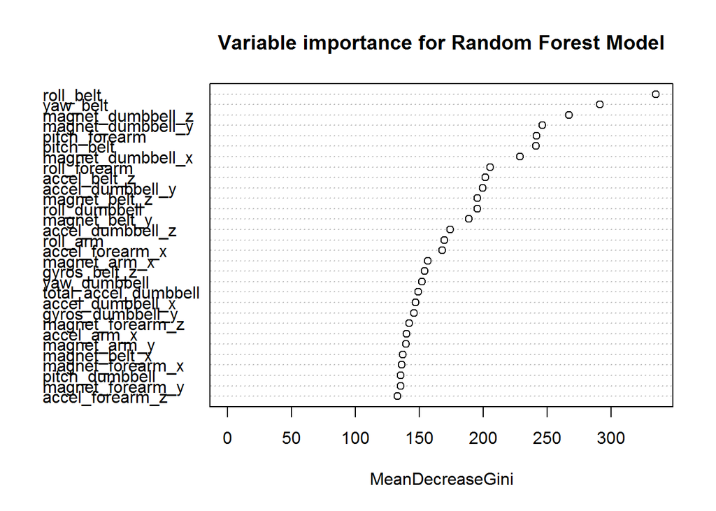

Among the most important variables, we see our previous observations are verified; “roll_belt” and “pitch_forearm” are indeed one of the most important variables in distinguishing betwee classes.

# Reference

Velloso, E.; Bulling, A.; Gellersen, H.; Ugulino, W.; Fuks, H. Qualitative Activity Recognition of Weight Lifting Exercises. Proceedings of 4th International Conference in Cooperation with SIGCHI (Augmented Human ’13) . Stuttgart, Germany: ACM SIGCHI, 2013.